# Assignment 3

The US Department of Agriculture publishes price estimates for fruits and vegetables [online](https://www.ers.usda.gov/data-products/fruit-and-vegetable-prices/fruit-and-vegetable-prices/). The most recent estimates are based on a 2013 survey of US retail stores.

The estimates are provided as a collection of MS Excel files, with one file per fruit or vegetable. The `assignment3_data.zip` file contains the fruit and vegetable files in the directories `fruit` and `vegetables`, respectively.

**Grade: 34/40**

- use rel paths
- combine back-to-back loops
- .xlsx not .xslsx (did you check your code?) </strong>

**Exercise 1.1.** Use pandas to extract the "Fresh" row(s) from the **fruit** Excel files. Combine the data into a single data frame. Your data frame should look something like this:

| type | food | form | price_per_lb | yield | lb_per_cup | price_per_cup |
| --- | --- | --- | --- | --- | --- | --- |
| fruit | watermelon | Fresh1 | 0.333412 | 0.52 | 0.330693 | 0.212033 |
| fruit | cantaloupe | Fresh1 | 0.535874 | 0.51 | 0.374786 | 0.3938 |
| vegetables | onions | Fresh1 | 1.03811 | 0.9 | 0.35274 | 0.406868 |
| ... |  |  |  |  |  |  |

It's okay if the rows and columns of your data frame are in a different order. These modules are especially relevant:

- [`str` methods](https://docs.python.org/2/library/stdtypes.html#string-methods)
- [`os`](https://docs.python.org/2/library/os.html)
- [`os.path`](https://docs.python.org/2/library/os.path.html)
- [pandas](http://pandas.pydata.org/pandas-docs/stable/): `read_excel()`, `concat()`, `.fillna()`, `.str`, plotting methods

Ask questions and search the documentation/web to find the functions you need.

```python
import numpy as np
import pandas as pd
import os
oldlist = os.listdir("/Users/ryanbrady/Desktop/141hw/Fruit")
lil = [x for x in oldlist if "~" not in x] # list the files
```

```python
%cd 'Fruit'
notwebscraped = [pd.read_excel(x) for x in lil]
for i in range(len(lil)):
    notwebscraped[i].iloc[:,5] = lil[i] # read in data
```

```
/Users/ryanbrady/Desktop/141hw/fruit
```

```python
for i in range(len(lil)): #get the fruits
    notwebscraped[i].iloc[:,2] = "fruit"
```

```python
for i in range(len(lil)):
    notwebscraped[i].iloc[:,5] = [x.rstrip(".xslsx") for x in notwebscraped[i].iloc[:,5]] #Loop to get fruit names
```

```python
for i in range(len(lil)): #limit each df to 7 columns
    notwebscraped[i] = notwebscraped[i].iloc[:,:7]
```

```python
# notwebscraped[1].iloc[:,0] = notwebscraped[i].iloc[:,0].dropna()
newdf = []
for i in range(len(lil)):
    notwebscraped[i].columns = ['form','price_per_lb','type','yield','lb_per_cup','food','price_per_cup'] #make them columns
```

```python
newdf = [] #new data frame
for i in range(len(lil)):
    newdf.append(notwebscraped[i])
ourdataframe = pd.concat(newdf)
ourdataframe = ourdataframe.dropna()
```

```python
datanon = ourdataframe.dropna()
```

```python
datanon.iloc[:,0] = datanon.iloc[:,0].str.lower()  #lower the names
```

```python
fruit = datanon[datanon['form'].str.contains("fresh")] #final fruit data
fruit
```

|  | form | price_per_lb | type | yield | lb_per_cup | food | price_per_cup |
| --- | --- | --- | --- | --- | --- | --- | --- |
| 2 | fresh1 | 1.56752 | fruit | 0.9 | 0.242508 | apple | 0.422373 |
| 2 | fresh1 | 3.04007 | fruit | 0.93 | 0.363763 | apricot | 1.1891 |
| 2 | fresh1 | 0.566983 | fruit | 0.64 | 0.330693 | banana | 0.292965 |
| 2 | fresh1 | 5.77471 | fruit | 0.96 | 0.31967 | blackberrie | 1.92292 |
| 2 | fresh1 | 4.73462 | fruit | 0.95 | 0.31967 | blueberrie | 1.59318 |
| 2 | fresh1 | 0.535874 | fruit | 0.51 | 0.374786 | cantaloupe | 0.3938 |
| 2 | fresh1 | 3.59299 | fruit | 0.92 | 0.341717 | cherrie | 1.33455 |
| 2 | fresh1 | 0.897802 | fruit | 0.49 | 0.462971 | grapefruit | 0.848278 |
| 2 | fresh1 | 2.09383 | fruit | 0.96 | 0.330693 | grape | 0.721266 |
| 2 | fresh1 | 0.796656 | fruit | 0.46 | 0.374786 | honeydew | 0.649077 |
| 2 | fresh1 | 2.04468 | fruit | 0.76 | 0.385809 | kiwi | 1.03797 |
| 2 | fresh1 | 1.37756 | fruit | 0.71 | 0.363763 | mangoe | 0.705783 |
| 2 | fresh1 | 1.76115 | fruit | 0.91 | 0.31967 | nectarine | 0.618667 |
| 2 | fresh1 | 1.03517 | fruit | 0.73 | 0.407855 | orange | 0.578357 |
| 2 | fresh1 | 1.29801 | fruit | 0.62 | 0.308647 | papaya | 0.646174 |
| 2 | fresh1 | 1.59119 | fruit | 0.96 | 0.341717 | peache | 0.56639 |
| 2 | fresh1 | 1.46157 | fruit | 0.9 | 0.363763 | pear | 0.59074 |
| 2 | fresh1 | 0.627662 | fruit | 0.51 | 0.363763 | pineapple | 0.447686 |
| 2 | fresh1 | 1.82742 | fruit | 0.94 | 0.363763 | plum | 0.707176 |
| 2 | fresh1 | 2.17359 | fruit | 0.56 | 0.341717 | pomegranate | 1.32634 |
| 2 | fresh1 | 6.97581 | fruit | 0.96 | 0.31967 | raspberrie | 2.32287 |
| 2 | fresh1 | 2.35881 | fruit | 0.94 | 0.31967 | strawberrie | 0.802171 |
| 2 | fresh1 | 1.37796 | fruit | 0.74 | 0.407855 | tangerine | 0.759471 |
| 2 | fresh1 | 0.333412 | fruit | 0.52 | 0.330693 | watermelon | 0.212033 |

```python
%cd vegetables
```

```
/Users/ryanbrady/Desktop/141hw/vegetables
```

**Grade: 7/10**

- list all problem files
- DRY (write funcs) </strong>

**Exercise 1.2.** Reuse your code from exercise 1.1 to extract the "Fresh" row(s) from the **vegetable** Excel files.

Does your code produce the correct prices for tomatoes? If not, why not? Do any other files have the same problem as the tomatoes file?

You don't need to extract the prices for these problem files. However, make sure the prices are extracted for files like asparagus that don't have this problem.

```python
veglist = os.listdir("/Users/ryanbrady/Desktop/141hw/vegetables")
veggies = [x for x in veglist if "~" not in x] # list the files
```

```python
vegwebscraped = [pd.read_excel(x) for x in veggies]

for i in range(len(veglist)):
    vegwebscraped[i].iloc[:,5] = veggies[i] # read in data
```

```python
for i in range(len(veglist)): #get the veg
    vegwebscraped[i].iloc[:,2] = "vegetable"
```

```python
for i in range(len(veglist)):
    vegwebscraped[i].iloc[:,5] = [x.rstrip(".xslsx") for x in vegwebscraped[i].iloc[:,5]] #Loop to getveg names
```

```python
for i in range(len(veglist)): #limit each df to 7 columns
    vegwebscraped[i] = vegwebscraped[i].iloc[:,:7]
```

```python
vegdf = []
for i in range(len(veglist)):
    vegwebscraped[i].columns = ['form','price_per_lb','type','yield','lb_per_cup','food','price_per_cup'] #make them columns
```

```python
for i in range(len(veglist)):
    vegdf.append(vegwebscraped[i])
vegdataframe = pd.concat(vegdf)
```

```python
vegnona = vegdataframe[~vegdataframe['form'].isnull()]
```

```python
vegnona.iloc[:,0] = vegnona.iloc[:,0].str.lower()  #lower the names
```

```python
veggies =vegnona[vegnona['form'].str.contains("fresh")] #final veg data
```

```python
veggies
```

|  | form | price_per_lb | type | yield | lb_per_cup | food | price_per_cup |
| --- | --- | --- | --- | --- | --- | --- | --- |
| 2 | fresh1 | 1.17225 | vegetable | 0.458554 | 0.451948 | acorn_squash | 1.15536 |
| 2 | fresh1 | 2.21305 | vegetable | 0.375309 | 0.385809 | artichoke | 2.27497 |
| 5 | 1includes globe and french artichokes; exclude... | NaN | vegetable | NaN | NaN | artichoke | NaN |
| 2 | fresh1 | 3.21349 | vegetable | 0.493835 | 0.396832 | asparagu | 2.58227 |
| 5 | 1includes green asparagus. it is assumed that ... | NaN | vegetable | NaN | NaN | asparagu | NaN |
| 2 | fresh1 | 2.23587 | vegetable | 0.740753 | 0.31967 | avocado | 0.964886 |
| 2 | fresh |  | vegetable |  |  | broccoli | NaN |
| 6 | 1it is assumed that fresh broccoli is boiled, ... | NaN | vegetable | NaN | NaN | broccoli | NaN |
| 2 | fresh1 | 2.76355 | vegetable | 1.06 | 0.341717 | brussels_sprout | 0.890898 |
| 4 | 1it is assumed that fresh brussels sprouts are... | NaN | vegetable | NaN | NaN | brussels_sprout | NaN |
| 2 | fresh1 | 1.24474 | vegetable | 0.714 | 0.451948 | butternut_squash | 0.787893 |
| 3 | 1it is assumed that butternut squash is baked ... | NaN | vegetable | NaN | NaN | butternut_squash | NaN |
| 2 | fresh green cabbage1 | 0.579208 | vegetable | 0.778797 | 0.330693 | cabbage | 0.245944 |
| 3 | fresh red cabbage1 | 1.05645 | vegetable | 0.779107 | 0.330693 | cabbage | 0.448412 |
| 2 | fresh | NaN | vegetable | NaN | NaN | carrot | NaN |
| 8 | 1whole carrots may be eaten fresh or cooked. e... | NaN | vegetable | NaN | NaN | carrot | NaN |
| 2 | fresh1 |  | vegetable |  |  | cauliflower | NaN |
| 6 | 1it is assumed that fresh cauliflower is cooke... | NaN | vegetable | NaN | NaN | cauliflower | NaN |
| 2 | fresh1 | NaN | vegetable | NaN | NaN | celery | NaN |
| 2 | fresh1 | 2.63084 | vegetable | 1.16 | 0.286601 | collard_green | 0.650001 |
| 5 | 1includes packaged, fresh-cut (e.g., cut or ch... | NaN | vegetable | NaN | NaN | collard_green | NaN |
| 2 | fresh1 | 2.69062 | vegetable | 0.54 | 0.363763 | corn_sweet | 1.8125 |
| 2 | fresh, consumed with peel1 | 1.29593 | vegetable | 0.97 | 0.264555 | cucumber | 0.353448 |
| 3 | fresh, peeled1 | 1.29593 | vegetable | 0.73 | 0.264555 | cucumber | 0.46965 |
| 2 | fresh1 | 2.13997 | vegetable | 0.846575 | 0.275578 | green_bean | 0.696606 |
| 5 | 1it is assumed that fresh green beans are cook... | NaN | vegetable | NaN | NaN | green_bean | NaN |
| 2 | fresh1 | 1.41036 | vegetable | 0.82 | 0.264555 | green_pepper | 0.455022 |
| 2 | fresh1 | 2.8073 | vegetable | 1.05 | 0.286601 | kale | 0.766262 |
| 5 | 1includes packaged, fresh-cut (e.g., cut or ch... | NaN | vegetable | NaN | NaN | kale | NaN |
| 2 | fresh1 | 1.21304 | vegetable | 0.95 | 0.242508 | lettuce_iceberg | 0.309655 |
| 2 | fresh1 |  | vegetable | NaN |  | lettuce_romaine | NaN |
| 2 | fresh1 | NaN | vegetable | NaN | NaN | mushroom | NaN |
| 5 | 1includes regular mushrooms (i.e., white butto... | NaN | vegetable | NaN | NaN | mushroom | NaN |
| 2 | fresh1 | 2.56924 | vegetable | 0.84 | 0.308647 | mustard_green | 0.944032 |
| 5 | 1includes packaged, fresh-cut (e.g., cut or ch... | NaN | vegetable | NaN | NaN | mustard_green | NaN |
| 2 | fresh1 | 3.21355 | vegetable | 0.769474 | 0.35274 | okra | 1.47315 |
| 2 | fresh1 | 1.03811 | vegetable | 0.9 | 0.35274 | onion | 0.406868 |
| 3 | 1excludes varieties such as scallions, shallot... | NaN | vegetable | NaN | NaN | onion | NaN |
| 2 | fresh1 | 0.56432 | vegetable | 0.811301 | 0.264555 | potatoe | 0.184017 |
| 5 | 1excludes red, fingerling, and creamer potatoe... | NaN | vegetable | NaN | NaN | potatoe | NaN |
| 2 | fresh1 | 1.31163 | vegetable | 0.9 | 0.275578 | radish | 0.401618 |
| 2 | fresh1 | 2.27794 | vegetable | 0.82 | 0.264555 | red_pepper | 0.734926 |
| 2 | fresh1 | NaN | vegetable | NaN | NaN | spinach | NaN |
| 2 | fresh1 | 1.63948 | vegetable | 0.7695 | 0.396832 | summer_squash | 0.84548 |
| 3 | 1includes geen and yellow zucchini. it is assu... | NaN | vegetable | NaN | NaN | summer_squash | NaN |
| 2 | fresh1 | 0.918897 | vegetable | 0.811301 | 0.440925 | sweet_potatoe | 0.4994 |
| 3 | 1it is assumed that consumers bake fresh sweet... | NaN | vegetable | NaN | NaN | sweet_potatoe | NaN |
| 2 | fresh | NaN | vegetable | NaN | NaN | tomatoe | NaN |
| 2 | fresh1 | 2.47175 | vegetable | 0.75 | 0.31967 | turnip_green | 1.05353 |
| 5 | 1includes packaged, fresh-cut (e.g., cut or ch... | NaN | vegetable | NaN | NaN | turnip_green | NaN |

My code does not produce the correct prices for tomatoes. Because tomatoes is not listed with fresh, but instead different descriptions of the tomatoes, the tomatoes get weeded out in the subsetting of the variables. Because many of the other vegetables are defined with multiple distinctions such as mushrooms which has different varieties of mushrooms. Another vegetable improperly stored would be lettuce. Broccoli does not have a price listednor does carrots,caulliflower or celery.

**Grade: 8/10**

- numeric cols? </strong>

**Exercise 1.3.** Remove rows without a price from the vegetable data frame and then combine the fruit and vegetable data frames. Make sure all columns of numbers are numeric (not strings).

```python
vegnull = veggies[~veggies['price_per_cup'].isnull()]
vegnull
```

|  | form | price_per_lb | type | yield | lb_per_cup | food | price_per_cup |
| --- | --- | --- | --- | --- | --- | --- | --- |
| 2 | fresh1 | 1.17225 | vegetable | 0.458554 | 0.451948 | acorn_squash | 1.15536 |
| 2 | fresh1 | 2.21305 | vegetable | 0.375309 | 0.385809 | artichoke | 2.27497 |
| 2 | fresh1 | 3.21349 | vegetable | 0.493835 | 0.396832 | asparagu | 2.58227 |
| 2 | fresh1 | 2.23587 | vegetable | 0.740753 | 0.31967 | avocado | 0.964886 |
| 2 | fresh1 | 2.76355 | vegetable | 1.06 | 0.341717 | brussels_sprout | 0.890898 |
| 2 | fresh1 | 1.24474 | vegetable | 0.714 | 0.451948 | butternut_squash | 0.787893 |
| 2 | fresh green cabbage1 | 0.579208 | vegetable | 0.778797 | 0.330693 | cabbage | 0.245944 |
| 3 | fresh red cabbage1 | 1.05645 | vegetable | 0.779107 | 0.330693 | cabbage | 0.448412 |
| 2 | fresh1 | 2.63084 | vegetable | 1.16 | 0.286601 | collard_green | 0.650001 |
| 2 | fresh1 | 2.69062 | vegetable | 0.54 | 0.363763 | corn_sweet | 1.8125 |
| 2 | fresh, consumed with peel1 | 1.29593 | vegetable | 0.97 | 0.264555 | cucumber | 0.353448 |
| 3 | fresh, peeled1 | 1.29593 | vegetable | 0.73 | 0.264555 | cucumber | 0.46965 |
| 2 | fresh1 | 2.13997 | vegetable | 0.846575 | 0.275578 | green_bean | 0.696606 |
| 2 | fresh1 | 1.41036 | vegetable | 0.82 | 0.264555 | green_pepper | 0.455022 |
| 2 | fresh1 | 2.8073 | vegetable | 1.05 | 0.286601 | kale | 0.766262 |
| 2 | fresh1 | 1.21304 | vegetable | 0.95 | 0.242508 | lettuce_iceberg | 0.309655 |
| 2 | fresh1 | 2.56924 | vegetable | 0.84 | 0.308647 | mustard_green | 0.944032 |
| 2 | fresh1 | 3.21355 | vegetable | 0.769474 | 0.35274 | okra | 1.47315 |
| 2 | fresh1 | 1.03811 | vegetable | 0.9 | 0.35274 | onion | 0.406868 |
| 2 | fresh1 | 0.56432 | vegetable | 0.811301 | 0.264555 | potatoe | 0.184017 |
| 2 | fresh1 | 1.31163 | vegetable | 0.9 | 0.275578 | radish | 0.401618 |
| 2 | fresh1 | 2.27794 | vegetable | 0.82 | 0.264555 | red_pepper | 0.734926 |
| 2 | fresh1 | 1.63948 | vegetable | 0.7695 | 0.396832 | summer_squash | 0.84548 |
| 2 | fresh1 | 0.918897 | vegetable | 0.811301 | 0.440925 | sweet_potatoe | 0.4994 |
| 2 | fresh1 | 2.47175 | vegetable | 0.75 | 0.31967 | turnip_green | 1.05353 |

```python
produce  = []
produce.append(fruit)
produce.append(vegnull)
fruitandveg = pd.concat(produce)
```

**Grade: 38/40**

- uninformative plot for Q1 </strong>

**Exercise 1.4.** Discuss the questions below (a paragraph each is sufficient). Use plots to support your ideas.

- What kinds of fruits are the most expensive (per pound)? What kinds are the least expensive?
- How do the price distributions compare for fruit and vegetables?
- Which foods are the best value for the price?
- What's something surprising about this data set?
- Which foods do you expect to provide the best combination of price, yield, and nutrition? A future assignment may combine this data set with another so you can check your hypothesis.

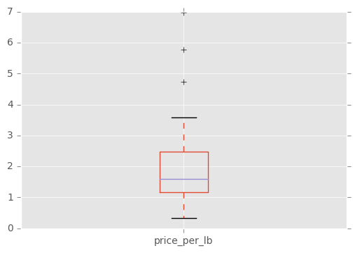

```python
import matplotlib.pyplot as plt
import matplotlib
matplotlib.style.use('ggplot')
fruitandveg['price_per_lb'].plot.box()
plt.show()
```

```python
byprice = fruitandveg.sort_values(by='price_per_lb', ascending=0)
byprice.iloc[:5,:]
```

|  | form | price_per_lb | type | yield | lb_per_cup | food | price_per_cup |
| --- | --- | --- | --- | --- | --- | --- | --- |
| 2 | fresh1 | 6.97581 | fruit | 0.96 | 0.31967 | raspberrie | 2.32287 |
| 2 | fresh1 | 5.77471 | fruit | 0.96 | 0.31967 | blackberrie | 1.92292 |
| 2 | fresh1 | 4.73462 | fruit | 0.95 | 0.31967 | blueberrie | 1.59318 |
| 2 | fresh1 | 3.59299 | fruit | 0.92 | 0.341717 | cherrie | 1.33455 |
| 2 | fresh1 | 3.21355 | vegetable | 0.769474 | 0.35274 | okra | 1.47315 |

```python
byprice.iloc[-5:,:]
```

|  | form | price_per_lb | type | yield | lb_per_cup | food | price_per_cup |
| --- | --- | --- | --- | --- | --- | --- | --- |
| 2 | fresh green cabbage1 | 0.579208 | vegetable | 0.778797 | 0.330693 | cabbage | 0.245944 |
| 2 | fresh1 | 0.566983 | fruit | 0.64 | 0.330693 | banana | 0.292965 |
| 2 | fresh1 | 0.56432 | vegetable | 0.811301 | 0.264555 | potatoe | 0.184017 |
| 2 | fresh1 | 0.535874 | fruit | 0.51 | 0.374786 | cantaloupe | 0.3938 |
| 2 | fresh1 | 0.333412 | fruit | 0.52 | 0.330693 | watermelon | 0.212033 |

From the box plot and tables which are sorted by price per pound we see that the three outliers of the plot are Rasberries, Blackeberries and Blueberries as the three highest priced per pound produce, all coming from the berry family. The two cheapest produce items both come from the melon family: Cantaloupe and Watermelon. Interestingly the cheapest and most expensive produce per pound are both fruit. This leads us into the question what is the difference in price distribution between fruits and vegetables.

# 2

```python
bp = fruitandveg[['price_per_lb','type']]
bp_veg = bp[bp['type'] == 'vegetable']
bp_fruit = bp[bp['type'] == 'fruit']
```

```python
bp['price_per_lb'] = pd.to_numeric(bp['price_per_lb'])
```

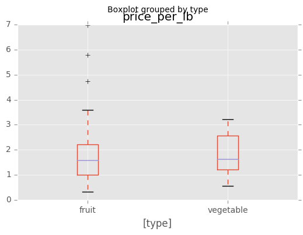

```python
bp.boxplot(by = 'type')
plt.show()
```

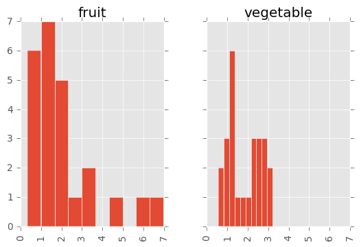

```python
bp.hist(by = 'type',sharex = True,sharey = True)
plt.show()
```

From both the histogram and box plot we see that the majority of fruits and vegetables fall in the .5 to 3.5 dollar range per pound. We also see that fruit has a couple of outliers, the three different types of berries. Vegetables have a slightly higher median than fruit.

# Best Price

The best priced fruits and vegetbales will be the ones that have the lowest price per pound.

```python
byprice.iloc[-5:,:]
```

|  | form | price_per_lb | type | yield | lb_per_cup | food | price_per_cup |
| --- | --- | --- | --- | --- | --- | --- | --- |
| 2 | fresh green cabbage1 | 0.579208 | vegetable | 0.778797 | 0.330693 | cabbage | 0.245944 |
| 2 | fresh1 | 0.566983 | fruit | 0.64 | 0.330693 | banana | 0.292965 |
| 2 | fresh1 | 0.56432 | vegetable | 0.811301 | 0.264555 | potatoe | 0.184017 |
| 2 | fresh1 | 0.535874 | fruit | 0.51 | 0.374786 | cantaloupe | 0.3938 |
| 2 | fresh1 | 0.333412 | fruit | 0.52 | 0.330693 | watermelon | 0.212033 |

The best priced produce include cabbages, bananas, potatoes, cantaloupes, and watermelons.

# 4

The most surprising thing about this data set is how much more expensive berries are compared to the rest of produce.

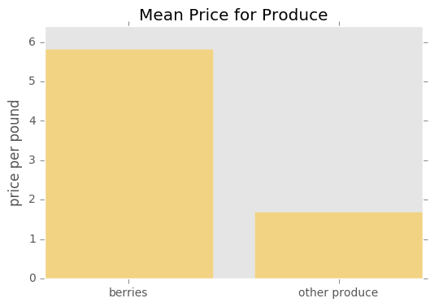

```python
berry = byprice.iloc[:3,1].mean()
other = byprice.iloc[3:,1].mean()
compare = [berry,other]

bar_labels = ['berries', 'other produce']
x_pos = list(range(len(bar_labels)))
plt.bar(x_pos,
        # using the data from the mean_values
        compare,

        # aligned in the center
        align='center',
        # with color
        color='#FFC225',
        # alpha 0.5
        alpha=0.5)
plt.grid()
max_y = max(zip(compare))
plt.ylim([0, (max_y[0]) * 1.1])
plt.ylabel('price per pound')
plt.xticks(x_pos, bar_labels)
plt.title('Mean Price for Produce')

plt.show()
```

This plot illustrates a difference of about four dollars per pound between the mean price of berries and all other produce.

```python
fruitandveg.iloc[:,1] = pd.to_numeric(fruitandveg.iloc[:,1])
fruitandveg.iloc[:,3] = pd.to_numeric(fruitandveg.iloc[:,3])
```

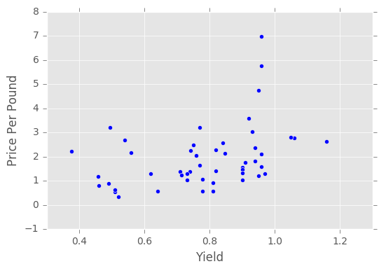

```python
plt.scatter(fruitandveg.iloc[:,3],fruitandveg.iloc[:,1])
plt.xlabel('Yield')
plt.ylabel('Price Per Pound')
plt.show()
```

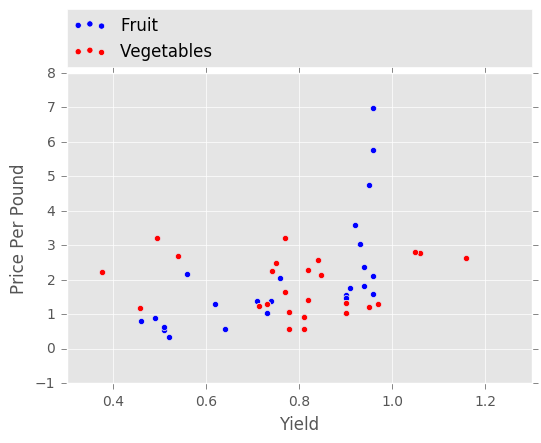

```python
plt.scatter(fruitandveg.iloc[:,3],fruitandveg.iloc[:,1],label = 'Fruit')
vegnull.iloc[:,1] = pd.to_numeric(vegnull.iloc[:,1])
vegnull.iloc[:,3] = pd.to_numeric(vegnull.iloc[:,3])
plt.scatter(vegnull.iloc[:,3],vegnull.iloc[:,1],c = 'r',label = 'Vegetables')
plt.legend(bbox_to_anchor=(0., 1.02, 1., .102), loc=3,
           ncol=1, mode="expand", borderaxespad=0.)
plt.xlabel('Yield')
plt.ylabel('Price Per Pound')

plt.show()
```

The best combination of price and yield would be fruits that are low in price and high in yield, to see this we will subset the dataframe to price per pound less than one dollar and fifty cents and yield greater than .8. Also of note, if we were to take out the berries, there seems to be a very slight trend as price per pound increases yield also increases. This trend seems to be more signifcant for fruit rather than vegetables though.

```python
lowprice  = fruitandveg[fruitandveg['price_per_lb'] < 1.5]
hylp = lowprice[lowprice['yield'] > 0.8]
hylp
```

|  | form | price_per_lb | type | yield | lb_per_cup | food | price_per_cup |
| --- | --- | --- | --- | --- | --- | --- | --- |
| 2 | fresh1 | 1.461575 | fruit | 0.900000 | 0.363763 | pear | 0.59074 |
| 2 | fresh, consumed with peel1 | 1.295931 | vegetable | 0.970000 | 0.264555 | cucumber | 0.353448 |
| 2 | fresh1 | 1.410363 | vegetable | 0.820000 | 0.264555 | green_pepper | 0.455022 |
| 2 | fresh1 | 1.213039 | vegetable | 0.950000 | 0.242508 | lettuce_iceberg | 0.309655 |
| 2 | fresh1 | 1.038107 | vegetable | 0.900000 | 0.35274 | onion | 0.406868 |
| 2 | fresh1 | 0.564320 | vegetable | 0.811301 | 0.264555 | potatoe | 0.184017 |
| 2 | fresh1 | 1.311629 | vegetable | 0.900000 | 0.275578 | radish | 0.401618 |
| 2 | fresh1 | 0.918897 | vegetable | 0.811301 | 0.440925 | sweet_potatoe | 0.4994 |

Almost exclusively vegetables contain the lowest price per lb with the highest yield. The only fruit in this grouping was pears. The produce with the highest nutritional value from this list are probably onions, radishes, and green peppers.